# Homework-Factors Affecting Temperature

S1C3 pyy

2023-10-19

# Overview

```r
head(airquality)
```

```
##   Ozone Solar.R Wind Temp Month Day
## 1    41     190  7.4   67     5   1
## 2    36     118  8.0   72     5   2
## 3    12     149 12.6   74     5   3
## 4    18     313 11.5   62     5   4
## 5    NA      NA 14.3   56     5   5
## 6    28      NA 14.9   66     5   6
```

```r
summary(airquality)
```

```
##      Ozone           Solar.R           Wind             Temp
##  Min.   :  1.00   Min.   :  7.0   Min.   : 1.700   Min.   :56.00
##  1st Qu.: 18.00   1st Qu.:115.8   1st Qu.: 7.400   1st Qu.:72.00
##  Median : 31.50   Median :205.0   Median : 9.700   Median :79.00
##  Mean   : 42.13   Mean   :185.9   Mean   : 9.958   Mean   :77.88
##  3rd Qu.: 63.25   3rd Qu.:258.8   3rd Qu.:11.500   3rd Qu.:85.00
##  Max.   :168.00   Max.   :334.0   Max.   :20.700   Max.   :97.00
##  NA's   :37       NA's   :7
##      Month            Day
##  Min.   :5.000   Min.   : 1.0
##  1st Qu.:6.000   1st Qu.: 8.0
##  Median :7.000   Median :16.0
##  Mean   :6.993   Mean   :15.8
##  3rd Qu.:8.000   3rd Qu.:23.0
##  Max.   :9.000   Max.   :31.0
##
```

This will give a brief view of the dataset “airquality”, which contains results from New York Air Quality Measurements from May 1, 1973 to Sept 30, 1973.

In total, there are 153 sets of data, but not all variables are available in each set, this will be shown later.

Variables:

1. Ozone: Mean ozone in parts per billion from 1300 to 1500 hours at Roosevelt Island
2. Solar.R: Solar radiation in Langleys in the frequency band 4000–7700 Angstroms from 0800 to 1200 hours at Central Park
3. Wind: Average wind speed in miles per hour at 0700 and 1000 hours at LaGuardia Airport
4. Temp: Maximum daily temperature in degrees Fahrenheit at La Guardia Airport.
5. Month
6. Day

Data explanation available at: https://vincentarelbundock.github.io/Rdatasets/doc/datasets/airquality.html.

# Plotting

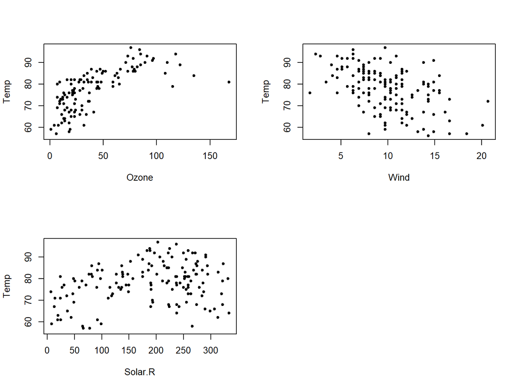

```r
par(mfrow = c(2, 2))
plot(Temp ~ Ozone, data = airquality, pch = 20)
plot(Temp ~ Wind, data = airquality, pch = 20)
plot(Temp ~ Solar.R, data = airquality, pch = 20)
```

**Question 1: How does variables like ozone, solar radiation, wind speed, month affect the temperature?**

Temperature vs Ozone: Temperature generally increases as ozone increases.

# Single Variable Linear Regression

**Question 2: What are the specific relationships?**

```r
lmO = lm(Temp ~ Ozone, data = airquality)
lmW = lm(Temp ~ Wind, data = airquality)
lmS = lm(Temp ~ Solar.R, data = airquality)
summary(lmO)
```

```
##
## Call:
## lm(formula = Temp ~ Ozone, data = airquality)
##
## Residuals:
##     Min      1Q  Median      3Q     Max
## -22.147  -4.858   1.828   4.342  12.328
##
## Coefficients:
##             Estimate Std. Error t value Pr(>|t|)
## (Intercept) 69.41072    1.02971   67.41   <2e-16 ***
## Ozone        0.20081    0.01928   10.42   <2e-16 ***
## ---
## Signif. codes:  0 '***' 0.001 '**' 0.01 '*' 0.05 '.' 0.1 ' ' 1
##
## Residual standard error: 6.819 on 114 degrees of freedom
##   (37 observations deleted due to missingness)
## Multiple R-squared:  0.4877, Adjusted R-squared:  0.4832
## F-statistic: 108.5 on 1 and 114 DF,  p-value: < 2.2e-16
```

```r
summary(lmW)
```

```
##
## Call:
## lm(formula = Temp ~ Wind, data = airquality)
##
## Residuals:
##     Min      1Q  Median      3Q     Max
## -23.291  -5.723   1.709   6.016  19.199
##
## Coefficients:
##             Estimate Std. Error t value Pr(>|t|)
## (Intercept)  90.1349     2.0522  43.921  < 2e-16 ***
## Wind         -1.2305     0.1944  -6.331 2.64e-09 ***
## ---
## Signif. codes:  0 '***' 0.001 '**' 0.01 '*' 0.05 '.' 0.1 ' ' 1
##
## Residual standard error: 8.442 on 151 degrees of freedom
## Multiple R-squared:  0.2098, Adjusted R-squared:  0.2045
## F-statistic: 40.08 on 1 and 151 DF,  p-value: 2.642e-09
```

```r
summary(lmS)
```

```
##
## Call:
## lm(formula = Temp ~ Solar.R, data = airquality)
##
## Residuals:
##      Min       1Q   Median       3Q      Max
## -22.3787  -4.9572   0.8932   5.9111  18.4013
##
## Coefficients:
##              Estimate Std. Error t value Pr(>|t|)
## (Intercept) 72.863012   1.693951  43.014  < 2e-16 ***
## Solar.R      0.028255   0.008205   3.444 0.000752 ***
## ---
## Signif. codes:  0 '***' 0.001 '**' 0.01 '*' 0.05 '.' 0.1 ' ' 1
##
## Residual standard error: 8.898 on 144 degrees of freedom
##   (7 observations deleted due to missingness)
## Multiple R-squared:  0.07609,    Adjusted R-squared:  0.06967
## F-statistic: 11.86 on 1 and 144 DF,  p-value: 0.0007518
```

Wind and Temperature, Solar Radiation and Temperature both only have very weak correlations,

# Visualization of Regression

Draw regression lines onto the scatter-plot graphs and also plot residual values.

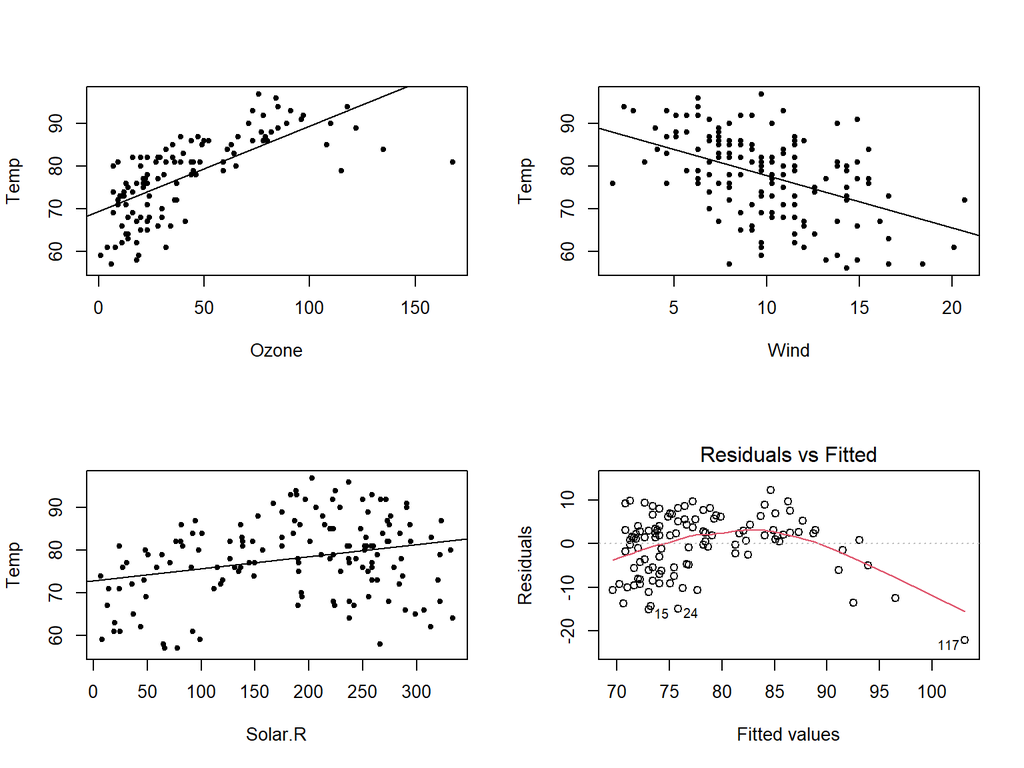

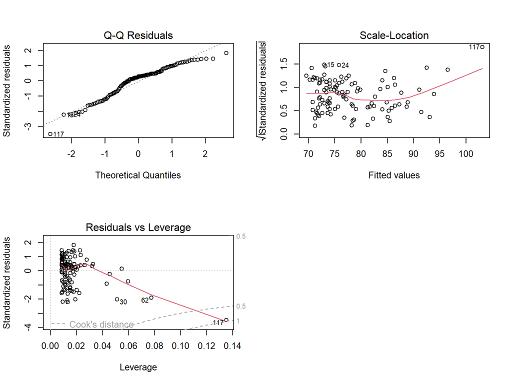

```r
par(mfrow = c(2, 2))
plot(Temp ~ Ozone, data = airquality, pch = 20)
abline(lmO)
plot(Temp ~ Wind, data = airquality, pch = 20)
abline(lmW)
plot(Temp ~ Solar.R, data = airquality, pch = 20)
abline(lmS)
plot(lmO)
```

# Small Improvements

It’s easy to see that their are a few outliers to the right side of the Ozone-Temperature graph, by remove this point and do the procedure above again:

```r
airquality_new = airquality[-c(117, 62, 30), ]
plot(Temp ~ Ozone, data = airquality_new, xlab = "Ozone", ylab = "Temp", pch = 20)
lmM_new = lm(Temp ~ Ozone, data = airquality_new)
summary(lmM_new)
```

```
##
## Call:
## lm(formula = Temp ~ Ozone, data = airquality_new)
##
## Residuals:
##      Min       1Q   Median       3Q      Max
## -14.8593  -4.5195   0.7666   4.4439  10.9891
##
## Coefficients:
##             Estimate Std. Error t value Pr(>|t|)
## (Intercept) 67.72242    0.97766   69.27   <2e-16 ***
## Ozone        0.25428    0.01995   12.74   <2e-16 ***
## ---
## Signif. codes:  0 '***' 0.001 '**' 0.01 '*' 0.05 '.' 0.1 ' ' 1
##
## Residual standard error: 6.137 on 111 degrees of freedom
##   (37 observations deleted due to missingness)
## Multiple R-squared:  0.5941, Adjusted R-squared:  0.5904
## F-statistic: 162.4 on 1 and 111 DF,  p-value: < 2.2e-16
```

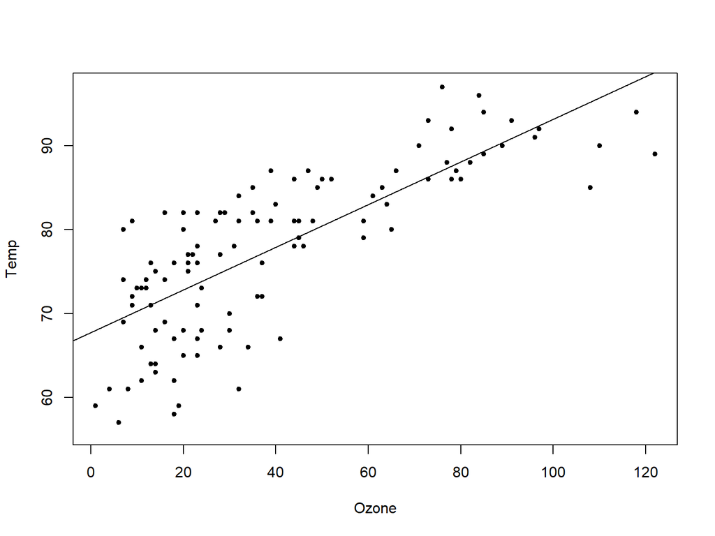

```r
abline(lmM_new)
```

Now it has a better correlation (R-square is bigger).

The regression equation is:

$$\hat{Temp} = 0.25428\times Ozone + 67.72242$$

# Multi Variable Linear Regression

**Question 3: How does these variable affect Temperature together?**

```r
lmOWS = lm(Temp ~ Ozone + Wind + Solar.R, data = airquality_new)
summary(lmOWS)
```

```
##
## Call:
## lm(formula = Temp ~ Ozone + Wind + Solar.R, data = airquality_new)
##
## Residuals:
##      Min       1Q   Median       3Q      Max
## -14.1594  -4.3307   0.1699   4.6272  11.9240
##
## Coefficients:
##              Estimate Std. Error t value Pr(>|t|)
## (Intercept) 70.164989   2.931269  23.937  < 2e-16 ***
## Ozone        0.234672   0.026624   8.814 2.97e-14 ***
## Wind        -0.238524   0.211007  -1.130    0.261
## Solar.R      0.003774   0.006959   0.542    0.589
## ---
## Signif. codes:  0 '***' 0.001 '**' 0.01 '*' 0.05 '.' 0.1 ' ' 1
##
## Residual standard error: 6.161 on 104 degrees of freedom
##   (42 observations deleted due to missingness)
## Multiple R-squared:  0.6028, Adjusted R-squared:  0.5913
## F-statistic: 52.61 on 3 and 104 DF,  p-value: < 2.2e-16
```

From the data, Wind Speed and Solar Radiation have low significance, which means they are not significantly related to Temperature.

# Prediction & Conclusion

The variable Ozone has the most correlation with Temperature.

The results above are not quite precise, but it’s still possible to predict (not so accurately) Temperature from Ozone.

**Question 4: Give example of predicting Temperature from Ozone using the regression equation above.**

1. For Ozone = $57$ ppb, $Temp = 0.25428\times57+67.72242=82.21638$

   The Temperature is approximately $82$ degrees Fahrenheit.
2. For Ozone = $68$ ppb: $Temp = 0.25428\times68+67.72242=85.01346$

   The Temperature is approximately $85$ degrees Fahrenheit.

# References

New York State Department of Conservation (ozone data) and the National Weather Service (meteorological data)